# IE6400 Foundations for Data Analytics Engineering

# Fall 2023

### Module 2: Probability Distribution

A **probability distribution** is a fundamental concept in statistics and probability theory that describes how the probabilities of different outcomes or events are distributed within a random experiment or random variable. It provides a mathematical framework for understanding uncertainty and randomness in various fields such as science, engineering, economics, and more.

#### Types of Probability Distributions

- There are two main types of probability distributions:
  - **Discrete Probability Distribution**: This type of distribution deals with random variables that can only take on a finite or countable number of distinct values. Examples include the binomial distribution, Poisson distribution, and geometric distribution.
  - **Continuous Probability Distribution**: Continuous distributions apply to random variables that can take on an infinite number of values within a certain range. Examples include the normal distribution, exponential distribution, and uniform distribution.

#### Common Probability Distributions

- **Normal Distribution**: Also known as the Gaussian distribution, it is widely used to model continuous data and is characterized by its bell-shaped curve.
- **Binomial Distribution**: Used for modeling the number of successes in a fixed number of independent Bernoulli trials.
- **Poisson Distribution**: Used to model the number of events occurring in a fixed interval of time or space when events are rare and random.
- **Exponential Distribution**: Models the time between events in a Poisson process.
- **Uniform Distribution**: Assigns equal probability to all values within a specified range.

#### Applications

- Probability distributions are used in a wide range of fields, including statistics, finance, engineering, science, and machine learning, to model and analyze uncertainty and randomness in data.

Understanding probability distributions is crucial for making informed decisions, conducting statistical analysis, and solving various real-world problems that involve randomness and uncertainty. Different types of probability distributions are chosen based on the characteristics of the data and the specific problem at hand.

#### Excercise 1 Probability Distribution of the Sum of Two Fair Six-Sided Dice Rolls

In this example, we will calculate and visualize the probability distribution for the sum of two fair six-sided dice rolls. The possible outcomes range from 2 (the minimum sum) to 12 (the maximum sum).

#### Step 1: Define the Sample Space

The sample space consists of all possible outcomes when rolling two fair six-sided dice. Each die can land on any number from 1 to 6. So, there are 6 possible outcomes for each die, and the total number of outcomes is 6 * 6 = 36.

#### Step 2: Calculate the Probability for Each Outcome

To calculate the probability distribution, we need to determine the probability of each possible sum from 2 to 12.

Let's use Python to calculate these probabilities.

```python
import numpy as np

# Define the sample space
sample_space = np.arange(2, 13)

# Initialize a dictionary to store probabilities
probabilities = {}

# Calculate probabilities for each sum
for sum_value in sample_space:
    count = np.sum(sample_space == sum_value)
    probability = count / 36.0
    probabilities[sum_value] = probability

probabilities
```

```
{2: 0.027777777777777776,
 3: 0.027777777777777776,
 4: 0.027777777777777776,
 5: 0.027777777777777776,
 6: 0.027777777777777776,
 7: 0.027777777777777776,
 8: 0.027777777777777776,
 9: 0.027777777777777776,
 10: 0.027777777777777776,
 11: 0.027777777777777776,
 12: 0.027777777777777776}
```

#### Step 3: Visualize the Probability Distribution

Now that we have calculated the probabilities for each possible sum, let's visualize the probability distribution using a bar chart.

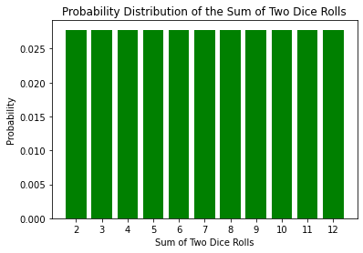

```python
import matplotlib.pyplot as plt

# Extract sums and corresponding probabilities
sums = list(probabilities.keys())
probs = list(probabilities.values())

# Create a bar chart
plt.bar(sums, probs, tick_label=sums, color='green')
plt.xlabel('Sum of Two Dice Rolls')
plt.ylabel('Probability')
plt.title('Probability Distribution of the Sum of Two Dice Rolls')
plt.show()
```

This bar chart will show the probability of each sum, ranging from 2 to 12.

#### Interpretation

This analysis provides insights into the likelihood of different outcomes when rolling two dice, which is useful in various games and probabilistic scenarios.

### Discrete Probability Distributions

#### Binomial Distribution

#### Excercise 2 Generating and Analyzing a Binomial Distribution with SciPy

**Objective:** In this exercise, you will use the SciPy library in Python to generate and analyze a binomial distribution. The binomial distribution is commonly used to model the number of successes in a fixed number of independent Bernoulli trials.

#### Instructions:

1. Import the necessary libraries

```python
import numpy as np
from scipy.stats import binom
import matplotlib.pyplot as plt
```

1. Define the parameters of the binomial distribution:
- **n (number of trials):** Choose a value such as 10, representing the number of trials or experiments.
- **p (probability of success):** Choose a value between 0 and 1, representing the probability of success in each trial.

```python
n = 10  # Number of trials
p = 0.3  # Probability of success
```

1. Use SciPy's binom function to create a binomial distribution object. Pass the values of n and p as arguments to the function:

```python
binomial_dist = binom(n, p)
```

1. Generate a list of possible outcomes (number of successes) from 0 to n using numpy. These will be the x-values for your probability distribution:

```python
x_values = np.arange(0, n+1)
```

1. Calculate the corresponding probabilities for each outcome using the pmf (probability mass function) method of the binomial distribution object:

```python
probabilities = binomial_dist.pmf(x_values)
```

1. Create a bar chart to visualize the binomial distribution using matplotlib.pyplot. Plot the x-values (number of successes) on the x-axis and the probabilities on the y-axis:

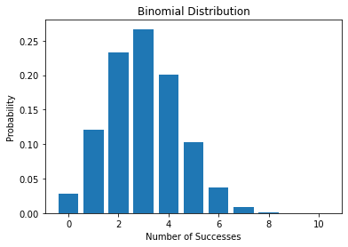

```python
plt.bar(x_values, probabilities)
plt.xlabel('Number of Successes')
plt.ylabel('Probability')
plt.title('Binomial Distribution')
plt.show()
```

#### Excercise 3 Calculating and Visualizing Binomial Probability Mass Function in Python

In this exercise, you will use Python to calculate and visualize the probability mass function (PMF) for a binomial distribution. The binomial PMF allows you to determine the probability of obtaining a specific number of successes in a fixed number of independent Bernoulli trials.

1. Import the necessary libraries

```python
from scipy.stats import binom
import matplotlib.pyplot as plt
```

1. Define the parameters of the binomial distribution:
- **n (number of trials):** Choose a value such as 10, representing the number of trials or experiments.
- **p (probability of success):** Choose a value between 0 and 1, representing the probability of success in each trial.
- **k_range (range of number of successes):** Create a range of values for k for which you want to calculate the probabilities.

```python
n = 10  # Number of trials
p = 0.3  # Probability of success
k_range = range(0, n+1)  # Range of possible numbers of successes
```

1. Use SciPy's binom function to create a binomial distribution object. Pass the values of n and p as arguments to the function:

```python
binomial_dist = binom(n, p)
```

1. Calculate the probabilities of obtaining different numbers of successes within the specified range k_range using a list comprehension:

```python
probabilities = [binomial_dist.pmf(k) for k in k_range]
```

1. Create a bar chart to visualize the binomial PMF. Plot the values of k_range on the x-axis and their respective probabilities on the y-axis:

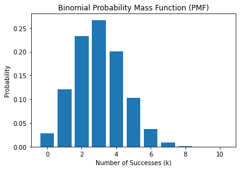

```python
plt.bar(k_range, probabilities)
plt.xlabel('Number of Successes (k)')
plt.ylabel('Probability')
plt.title('Binomial Probability Mass Function (PMF)')
plt.show()
```

#### Objective:

In this exercise, we will:

1. Generate random samples from a negative binomial distribution.
2. Visualize the distribution.
3. Interpret the results.

#### Step 1: Importing Necessary Libraries

```python
import numpy as np
import matplotlib.pyplot as plt
import seaborn as sns
```

#### Step 2: Generating Random Samples

We'll use `numpy` to generate random samples from a negative binomial distribution. The function `np.random.negative_binomial(n, p, size)` is used for this purpose, where:

- `n` is the number of successes.
- `p` is the probability of a success.
- `size` is the number of samples to generate.

```python
n = 5  # number of successes
p = 0.5  # probability of a success
size = 1000  # number of samples

samples = np.random.negative_binomial(n, p, size)
```

#### Step 3: Visualization

We'll use `seaborn` to visualize the distribution of our generated samples.

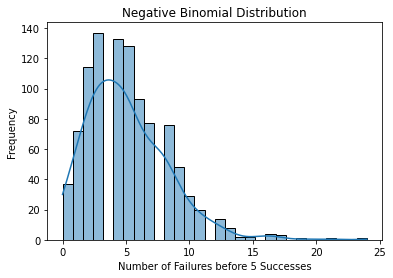

```python
sns.histplot(samples, bins=30, kde=True)
plt.title('Negative Binomial Distribution')
plt.xlabel('Number of Failures before 5 Successes')
plt.ylabel('Frequency')
plt.show()
```

#### Step 4: Interpretation

From the visualization, we can observe the distribution of the number of failures before achieving 5 successes. The peak of the distribution indicates the most likely number of failures before 5 successes are achieved, given a success probability of 0.5.

The spread of the distribution provides insight into the variability of the number of failures. A wider spread indicates greater variability, while a narrower spread indicates more consistency in the number of failures before achieving the desired number of successes.

#### Conclusion

The negative binomial distribution provides a way to model the number of failures before a specified number of successes occur. By understanding and visualizing this distribution, we can gain insights into the variability and likelihood of different outcomes in scenarios that fit this model.

#### Exercise 5 Applying the Negative Binomial Distribution to a Dataset

In this exercise, we will:

1. Generate a dataset with a known negative binomial distribution.
2. Apply the negative binomial distribution to estimate the parameters.
3. Visualize the actual vs. estimated distribution.
4. Interpret the results.

#### Step 1: Importing Necessary Libraries

```python
import numpy as np
import matplotlib.pyplot as plt
import seaborn as sns
from scipy.stats import nbinom
```

#### Step 2: Generating the Dataset

We'll use `numpy` to generate a dataset with a known negative binomial distribution. This dataset will simulate the number of failures before a certain number of successes are achieved.

```python
n_actual = 7  # actual number of successes
p_actual = 0.4  # actual probability of a success
size = 5000  # number of samples

dataset = np.random.negative_binomial(n_actual, p_actual, size)
```

#### Step 3: Estimating Parameters

We'll use the mean and variance of the dataset to estimate the parameters `n` (number of successes) and `p` (probability of success) for the negative binomial distribution.

Given:

- Mean = `n * (1-p) / p`
- Variance = `n * (1-p) / p^2`

We can rearrange the formulas to solve for `n` and `p`.

```python
mean = np.mean(dataset)
variance = np.var(dataset)

# Estimating p using the relationship between mean and variance
p_estimated = mean / variance

# Estimating n using the estimated p
n_estimated = mean * p_estimated / (1 - p_estimated)
```

#### Step 4: Visualization

We'll visualize the actual vs. estimated distribution using histograms and probability mass functions (PMFs).

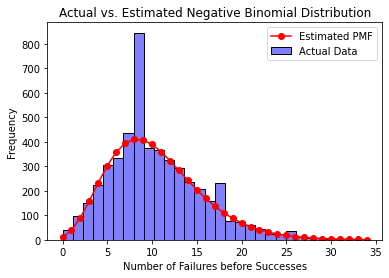

```python
# Plotting the actual dataset histogram
sns.histplot(dataset, bins=30, kde=False, label='Actual Data', color='blue', alpha=0.5)

# Plotting the estimated PMF
x = np.arange(0, max(dataset)+1)
plt.plot(x, nbinom.pmf(x, n_estimated, p_estimated) * size, 'o-', label='Estimated PMF', color='red')

plt.title('Actual vs. Estimated Negative Binomial Distribution')
plt.xlabel('Number of Failures before Successes')
plt.ylabel('Frequency')
plt.legend()
plt.show()
```

#### Interpretation

From the visualization, we can compare the actual data distribution with the estimated negative binomial distribution. The red dots represent the estimated probability mass function (PMF) based on the parameters we derived from the dataset.

If the estimation is accurate, the red dots should align closely with the peaks of the blue histogram bars. Discrepancies between the two might suggest that the dataset doesn't perfectly follow a negative binomial distribution or that there's variability inherent in the sample.

#### Conclusion

By applying the negative binomial distribution to a generated dataset, we can estimate its parameters and visualize how well the estimated distribution fits the actual data. This exercise demonstrates the practical application of the negative binomial distribution in analyzing real-world datasets.

#### Poisson Distribution

#### Excercise 6 Understanding the Poisson Distribution

The Poisson distribution is a discrete probability distribution that expresses the probability of a given number of events occurring in a fixed interval of time or space. These events must occur with a known constant mean rate and be independent of the time since the last event.

#### Objective:

In this exercise, we will:

1. Generate random samples from a Poisson distribution.
2. Visualize the distribution.
3. Interpret the results.

#### Step 1: Importing Necessary Libraries

```python
import numpy as np
import matplotlib.pyplot as plt
import seaborn as sns
```

#### Step 2: Generating Random Samples

We'll use `numpy` to generate random samples from a Poisson distribution. The function `np.random.poisson(lambda, size)` is used for this purpose, where:

- `lambda` is the expected number of events in the interval (also known as the rate of occurrence).
- `size` is the number of samples to generate.

```python
lambda_val = 5  # expected number of events in the interval
size = 1000  # number of samples

samples = np.random.poisson(lambda_val, size)
```

#### Step 3: Visualization

We'll use `seaborn` to visualize the distribution of our generated samples.

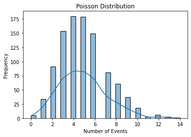

```python
sns.histplot(samples, bins=30, kde=True)
plt.title('Poisson Distribution')
plt.xlabel('Number of Events')
plt.ylabel('Frequency')
plt.show()
```

#### Interpretation

From the visualization, we can observe the distribution of the number of events occurring in the fixed interval. The peak of the distribution indicates the most likely number of events to occur in the interval, given the expected rate of occurrence (`lambda`).

The spread of the distribution provides insight into the variability of the number of events. A wider spread indicates greater variability, while a narrower spread suggests more consistency in the number of events in the interval.

#### Conclusion

The Poisson distribution is a useful tool for modeling the number of events that occur in a fixed interval of time or space. By understanding and visualizing this distribution, we can gain insights into the likelihood and variability of different outcomes in scenarios that fit this model.

#### Hypergeometric Distribution

#### Excercise 7 Understanding the Hypergeometric Distribution

The hypergeometric distribution is a discrete probability distribution that describes the probability of k successes in n draws, without replacement, from a finite population of size N that contains exactly K successes.

For example, imagine you have a deck of cards, and you want to know the probability of drawing a certain number of aces in a fixed number of draws.

#### Objective:

In this exercise, we will:

1. Generate random samples from a hypergeometric distribution.
2. Visualize the distribution.
3. Interpret the results.

#### Step 1: Importing Necessary Libraries

```python
import numpy as np
import matplotlib.pyplot as plt
import seaborn as sns
```

#### Step 2: Generating Random Samples

We'll use `numpy` to generate random samples from a hypergeometric distribution. The function `np.random.hypergeometric(NGood, NBad, nsample, size)` is used for this purpose, where:

- `NGood` is the number of successes in the population.
- `NBad` is the number of failures in the population.
- `nsample` is the number of draws.
- `size` is the number of samples to generate.

```python
NGood = 10  # number of successes in the population
NBad = 20  # number of failures in the population
nsample = 5  # number of draws
size = 1000  # number of samples

samples = np.random.hypergeometric(NGood, NBad, nsample, size)
```

#### Step 3: Visualization

We'll use `seaborn` to visualize the distribution of our generated samples.

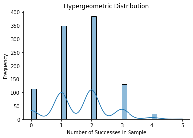

```python
sns.histplot(samples, bins=30, kde=True)
plt.title('Hypergeometric Distribution')
plt.xlabel('Number of Successes in Sample')
plt.ylabel('Frequency')
plt.show()
```

#### Interpretation

From the visualization, we can observe the distribution of the number of successes in our sample. The peak of the distribution indicates the most likely number of successes to be drawn in the sample, given the number of successes and failures in the population.

The spread of the distribution provides insight into the variability of the number of successes. A wider spread indicates greater variability, while a narrower spread suggests more consistency in the number of successes in the sample.

#### Conclusion

The hypergeometric distribution is a useful tool for modeling the number of successes in a sample drawn without replacement from a finite population. By understanding and visualizing this distribution, we can gain insights into the likelihood and variability of different outcomes in scenarios that fit this model.

#### Multivariate Hypergeometric Distribution

#### Exercise 8 Understanding the Multivariate Hypergeometric Distribution

The multivariate hypergeometric distribution is a generalization of the hypergeometric distribution. It describes probabilities when sampling without replacement from a population consisting of several classes. For instance, consider drawing cards from a deck and wanting to know the probability of drawing a certain number of each suit.

#### Objective:

In this exercise, we will:

1. Generate random samples from a multivariate hypergeometric distribution.
2. Visualize the distribution.
3. Interpret the results.

#### Step 1: Importing Necessary Libraries

```python
import numpy as np
import matplotlib.pyplot as plt
import seaborn as sns
from scipy.stats import hypergeom
```

#### Step 2: Generating Random Samples

We'll use `scipy.stats` to generate random samples from a hypergeometric distribution as an approximation to the multivariate case.

```python
colors = [13, 13, 13, 13]  # 13 cards of each suit in a deck: Hearts, Diamonds, Clubs, Spades
nsample = 10  # number of draws
size = 1000  # number of samples

M = sum(colors)  # total number of cards
N = nsample  # number of draws

# Generate samples for each suit
samples = np.array([hypergeom.rvs(M, color, N, size=size) for color in colors]).T
```

#### Step 3: Visualization

We'll visualize the distribution of our generated samples for each class (suit in our example).

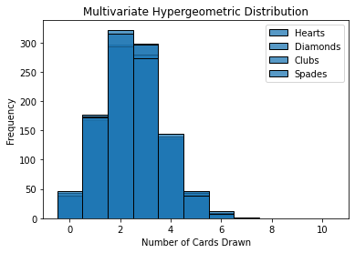

```python
# Plotting the distribution for each suit
suits = ['Hearts', 'Diamonds', 'Clubs', 'Spades']

for idx, suit in enumerate(suits):
    sns.histplot(samples[:, idx], bins=np.arange(-0.5, nsample+1.5), kde=False, label=suit)

plt.title('Multivariate Hypergeometric Distribution')
plt.xlabel('Number of Cards Drawn')
plt.ylabel('Frequency')
plt.legend()
plt.show()
```

#### Interpretation

From the visualization, we can observe the distribution of the number of cards drawn for each suit. The histograms represent the likelihood of drawing a specific number of cards for each suit in the given number of draws.

The spread of each distribution provides insight into the variability of the number of cards drawn for each suit. A wider spread indicates greater variability, while a narrower spread suggests more consistency in the number of cards drawn for that suit.

#### Conclusion

The multivariate hypergeometric distribution is a powerful tool for modeling the number of items drawn from multiple classes in a sample without replacement. By understanding and visualizing this distribution, we can gain insights into the likelihood and variability of different outcomes in scenarios that fit this model.

### Continuous Probability Distributions

#### Uniform Distribution

#### Exercise 9 Understanding the Uniform Distribution

The uniform distribution is a type of probability distribution in which all outcomes are equally likely. A deck of cards has a uniform distribution because the likelihood of drawing any particular card is the same.

In this exercise, we will simulate a scenario where we measure the time (in hours) it takes for a computer system to process a batch of tasks. We assume that the processing time is uniformly distributed between 2 to 10 hours.

#### Objective:

In this exercise, we will:

1. Generate random samples from a uniform distribution.
2. Visualize the distribution.
3. Interpret the results.

#### Step 1: Importing Necessary Libraries

```python
import numpy as np
import matplotlib.pyplot as plt
import seaborn as sns
```

#### Step 2: Generating Random Samples

We'll use `numpy` to generate random samples from a uniform distribution. The function `np.random.uniform(low, high, size)` is used for this purpose, where:

- `low` is the lower boundary of the output interval.
- `high` is the upper boundary of the output interval.
- `size` is the number of samples to generate.

```python
low = 2  # 2 hours
high = 10  # 10 hours
size = 1000  # number of samples

samples = np.random.uniform(low, high, size)
```

#### Step 3: Visualization

We'll use `seaborn` to visualize the distribution of our generated samples.

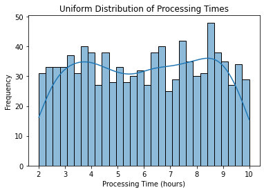

```python
sns.histplot(samples, bins=30, kde=True)
plt.title('Uniform Distribution of Processing Times')
plt.xlabel('Processing Time (hours)')
plt.ylabel('Frequency')
plt.show()
```

#### Interpretation

From the visualization, we can observe that the processing time for the tasks is uniformly distributed between 2 to 10 hours. This means that any specific time within this range is just as likely as any other, making it a fair and equal distribution.

In practical scenarios, a uniform distribution might not always be realistic, but it serves as a useful starting point or baseline model in many situations.

#### Conclusion

The uniform distribution provides a model where every outcome in a specified range is equally likely. By understanding and visualizing this distribution, we can gain insights into scenarios where all outcomes have an equal chance of occurring.

#### Normal Distribution

#### Exercise 10 Understanding the Normal Distribution

The normal distribution, also known as the Gaussian distribution, is a probability distribution that is symmetric about the mean, showing that data near the mean are more frequent in occurrence than data far from the mean.

Imagine a scenario where we are analyzing the scores of students in a national examination. Typically, a large number of students will score around the average, while fewer students will score very high or very low. This distribution of scores often follows a normal distribution.

#### Objective:

In this exercise, we will:

1. Generate random samples from a normal distribution.
2. Visualize the distribution.
3. Interpret the results.

#### Step 1: Importing Necessary Libraries

```python
import numpy as np
import matplotlib.pyplot as plt
import seaborn as sns
```

#### Step 2: Generating Random Samples

We'll use `numpy` to generate random samples from a normal distribution. The function `np.random.normal(mean, std, size)` is used for this purpose, where:

- `mean` is the mean (center) of the distribution.
- `std` is the standard deviation (spread or width) of the distribution.
- `size` is the number of samples to generate.

```python
mean = 50  # average score
std = 10  # standard deviation
size = 1000  # number of samples

samples = np.random.normal(mean, std, size)
```

#### Step 3: Visualization

We'll use `seaborn` to visualize the distribution of our generated samples.

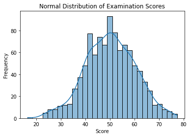

```python
sns.histplot(samples, bins=30, kde=True)
plt.title('Normal Distribution of Examination Scores')
plt.xlabel('Score')
plt.ylabel('Frequency')
plt.show()
```

#### Interpretation

From the visualization, we can observe that the examination scores are normally distributed around the mean score of 50. The spread of the scores is determined by the standard deviation, which in this case is 10. This means that most students scored within a range of 40 to 60.

The bell shape of the normal distribution indicates that scores close to the mean are more frequent in occurrence than scores far from the mean. As we move further from the mean in either direction, the frequency of scores decreases, which is a characteristic property of the normal distribution.

#### Conclusion

The normal distribution is one of the most important and widely used distributions in statistics. It's essential in various fields, from finance to natural sciences. Understanding the properties and behavior of the normal distribution is crucial for anyone working with data.

#### Lognormal Distribution

#### Exercise 11 Understanding the Log-Normal Distribution

The log-normal distribution is a probability distribution of a random variable whose logarithm is normally distributed. It is useful in describing variables that are always positive and have a long tail, such as the distribution of incomes, stock prices, or even the size of particles generated by a process.

Imagine a scenario where we are analyzing the distribution of incomes in a city. While most people might earn an average income, there will be a few who earn significantly more, leading to a skewed distribution. The incomes in such scenarios can often be modeled using a log-normal distribution.

#### Objective:

In this exercise, we will:

1. Generate random samples from a log-normal distribution.
2. Visualize the distribution.
3. Interpret the results.

#### Step 1: Importing Necessary Libraries

```python
import numpy as np
import matplotlib.pyplot as plt
import seaborn as sns
```

#### Step 2: Generating Random Samples

We'll use `numpy` to generate random samples from a log-normal distribution. The function `np.random.lognormal(mean, sigma, size)` is used for this purpose, where:

- `mean` is the mean of the logarithm of the distribution.
- `sigma` is the standard deviation of the logarithm of the distribution.
- `size` is the number of samples to generate.

```python
mean = 0  # mean of the logarithm
sigma = 0.5  # standard deviation of the logarithm
size = 1000  # number of samples

samples = np.random.lognormal(mean, sigma, size)
```

#### Step 3: Visualization

We'll use `seaborn` to visualize the distribution of our generated samples.

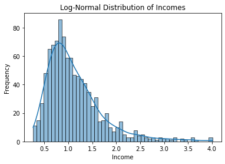

```python
sns.histplot(samples, bins=50, kde=True)
plt.title('Log-Normal Distribution of Incomes')
plt.xlabel('Income')
plt.ylabel('Frequency')
plt.show()
```

#### Interpretation

From the visualization, we can observe that the incomes are log-normally distributed. Most people earn an average income, but there's a long tail on the right, indicating that there are a few people who earn significantly more. This right-skewed distribution is characteristic of the log-normal distribution.

The log-normal distribution is particularly useful for describing variables that can't take negative values and have a skewed distribution. The long tail on the right indicates the presence of outliers or extreme values that are significantly higher than the mean.

#### Conclusion

The log-normal distribution is a versatile tool for modeling skewed distributions in various fields. Understanding its properties and behavior is crucial for analyzing datasets where the majority of observations are clustered around the lower values, but a few extreme values pull the mean upwards.

#### Gamma Distribution

#### Exercise 12 Understanding the Gamma Distribution

The gamma distribution is a continuous probability distribution that represents the waiting time until the k-th event in a Poisson process with a known average rate of occurrence. It's often used in various fields such as finance, insurance, and natural sciences to model continuous variables that are always positive and have skewed distributions.

Imagine a scenario where we are analyzing the time (in hours) it takes for a certain chemical reaction to complete k times. Given that the reaction follows a Poisson process, the waiting times can be modeled using a gamma distribution.

#### Objective:

In this exercise, we will:

1. Generate random samples from a gamma distribution.
2. Visualize the distribution.
3. Interpret the results.

#### Step 1: Importing Necessary Libraries

```python
import numpy as np
import matplotlib.pyplot as plt
import seaborn as sns
```

#### Step 2: Generating Random Samples

We'll use `numpy` to generate random samples from a gamma distribution. The function `np.random.gamma(shape, scale, size)` is used for this purpose, where:

- `shape` (often denoted as k) is the shape parameter, which is the number of events.
- `scale` (often denoted as θ) is the scale parameter, which is the average interval between events.
- `size` is the number of samples to generate.

```python
shape = 2  # number of events
scale = 1  # average interval between events
size = 1000  # number of samples

samples = np.random.gamma(shape, scale, size)
```

#### Step 3: Visualization

We'll use `seaborn` to visualize the distribution of our generated samples.

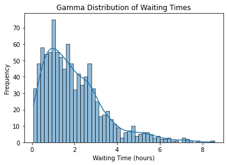

```python
sns.histplot(samples, bins=50, kde=True)
plt.title('Gamma Distribution of Waiting Times')
plt.xlabel('Waiting Time (hours)')
plt.ylabel('Frequency')
plt.show()
```

#### Interpretation

The gamma distribution is particularly useful for modeling the amount of time until the next event in scenarios where events occur at a known average rate. The shape and scale parameters determine the form and spread of the distribution, allowing it to model a wide range of scenarios.

#### Conclusion

The gamma distribution is a powerful tool for modeling waiting times in various fields. Understanding its properties and behavior is crucial for analyzing datasets where the time until the next event is of interest, especially in scenarios that follow a Poisson process.

#### Exponential Distribution

#### Exercise 13 Understanding the Exponential Distribution

The exponential distribution is a continuous probability distribution that represents the time between events in a Poisson process. It's often used to model the time between rare events, such as the time between customer arrivals or the time between equipment failures.

Imagine a scenario where we are analyzing the time (in hours) between successive breakdowns of a machine in a factory. Given that the breakdowns follow a Poisson process, the time intervals between these breakdowns can be modeled using an exponential distribution.

#### Objective:

In this exercise, we will:

1. Generate random samples from an exponential distribution.
2. Visualize the distribution.
3. Interpret the results.

#### Step 1: Importing Necessary Libraries

```python
import numpy as np
import matplotlib.pyplot as plt
import seaborn as sns
```

#### Step 2: Generating Random Samples

We'll use `numpy` to generate random samples from an exponential distribution. The function `np.random.exponential(scale, size)` is used for this purpose, where:

- `scale` (often denoted as β) is the inverse of the rate parameter (λ), which represents the average time between events.
- `size` is the number of samples to generate.

```python
scale = 5  # average time (in hours) between breakdowns
size = 1000  # number of samples

samples = np.random.exponential(scale, size)
```

#### Step 3: Visualization

We'll use `seaborn` to visualize the distribution of our generated samples.

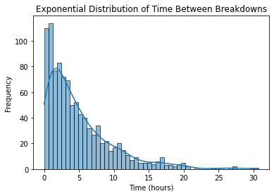

```python
sns.histplot(samples, bins=50, kde=True)
plt.title('Exponential Distribution of Time Between Breakdowns')
plt.xlabel('Time (hours)')
plt.ylabel('Frequency')
plt.show()
```

#### Step 4: Interpretation

From the visualization, we can observe that the time intervals between machine breakdowns are exponentially distributed. Most of the breakdowns occur within a shorter time frame, but there's a long tail on the right, indicating that occasionally, the machine can operate for a significantly longer time without breaking down. This decreasing nature is characteristic of the exponential distribution.

The exponential distribution is particularly useful for modeling the time between events in scenarios where events occur independently and at a constant average rate. The scale parameter determines the average time between events, which in turn shapes the distribution.

#### Conclusion

The exponential distribution is a key tool for modeling the time between events in various fields. Understanding its properties and behavior is crucial for analyzing datasets where the time until the next event is of interest, especially in scenarios that follow a Poisson process.

#### Revised Date: October 28, 2023